# Medical Cost Analysis

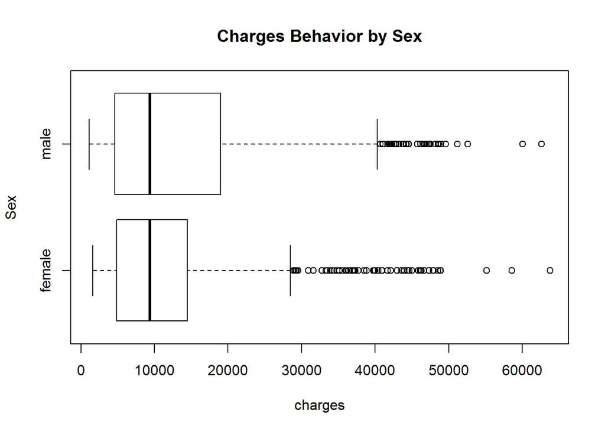

- As we stated earlier, charges column contains outliers values.
- The median charge is the same for both men and women.
- Men tend to spend more money in medical insurances.

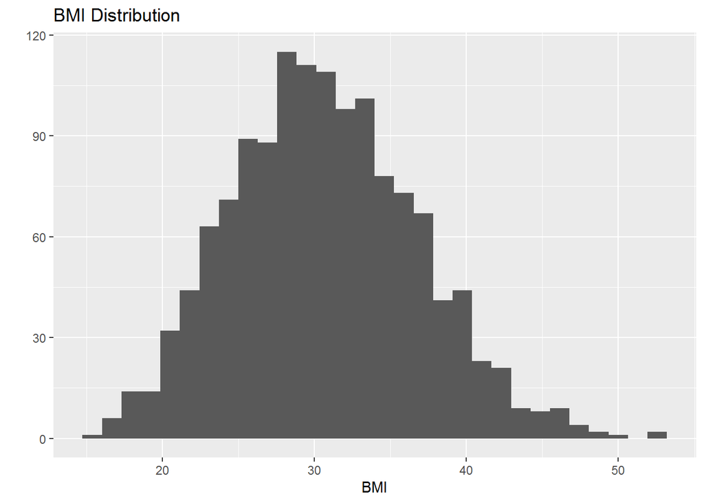

* The BMI data shows a normal distribution with the mean value placed un 30. According to the internet, obesity starts with a BMI of 30. * It’s interesting to see the charges behavior related to the BMI.

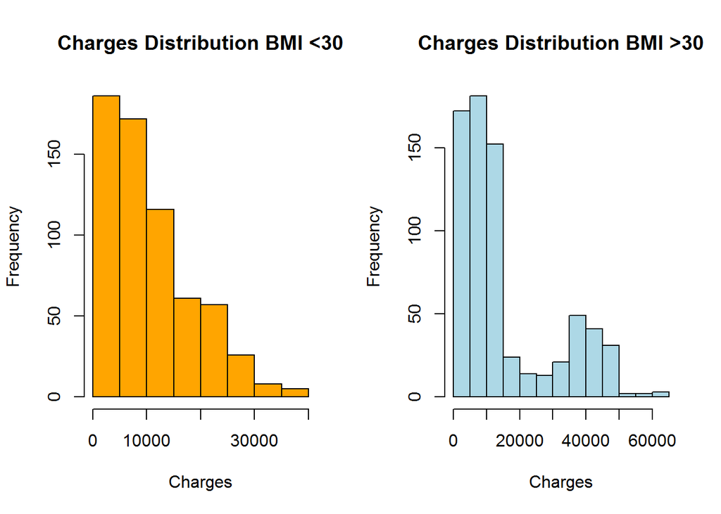

- People with a BMI over 30 spend more money in medical insurances.

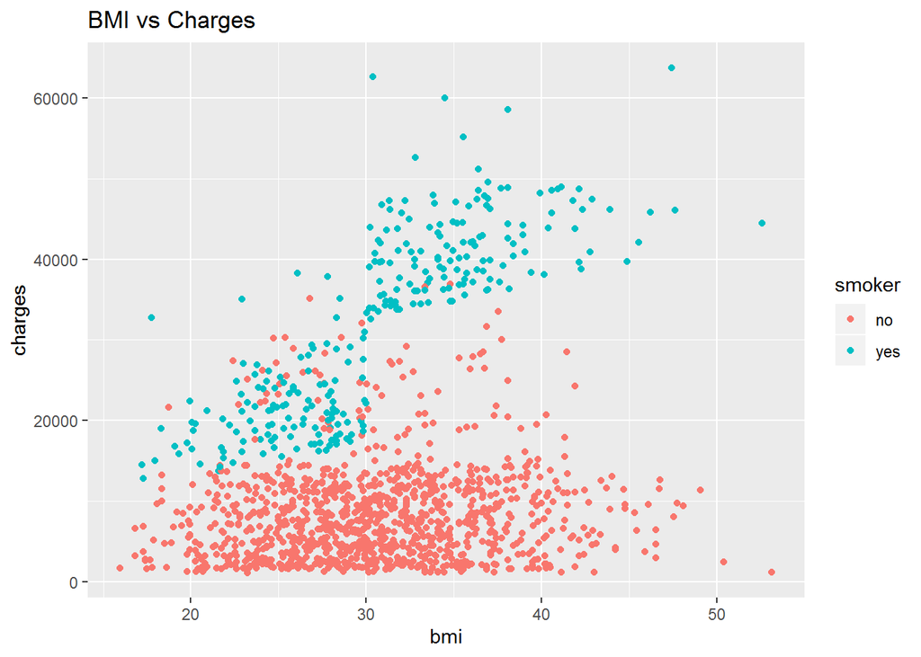

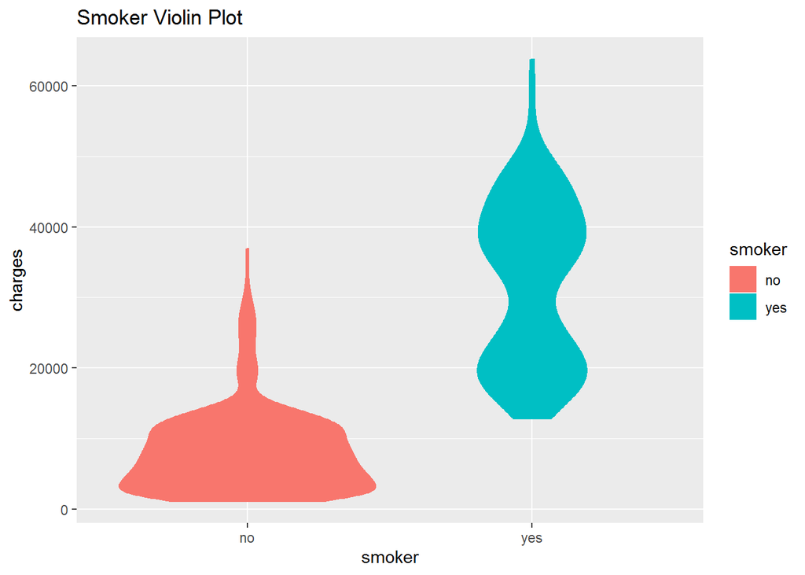

- As we can see, smoker pay more for medical insurances.
- Charges for non-smoker people tend to be low.

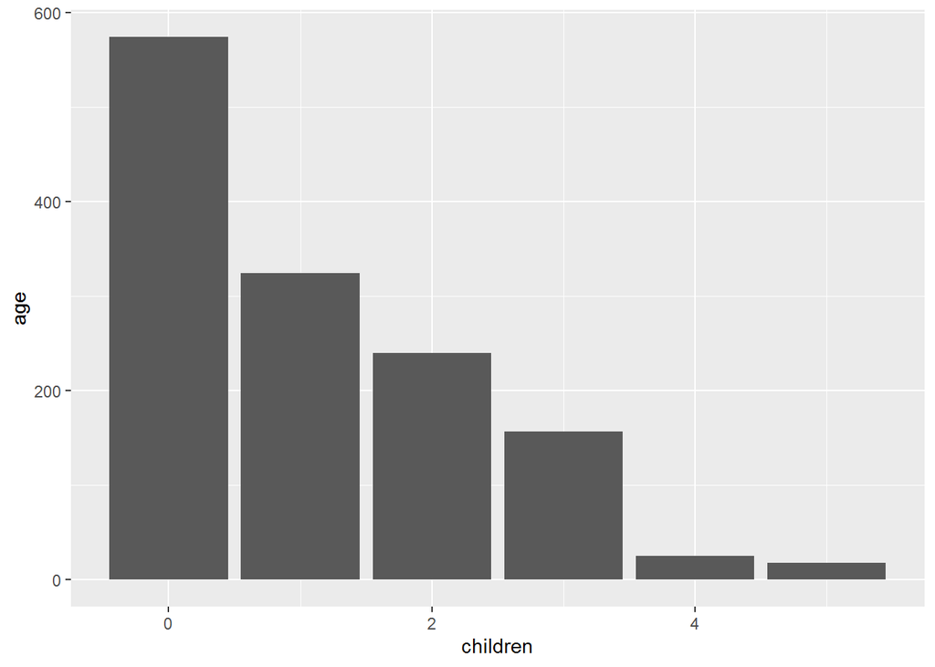

People with no children prevail in the dataset. Let’s see how much money they pay.

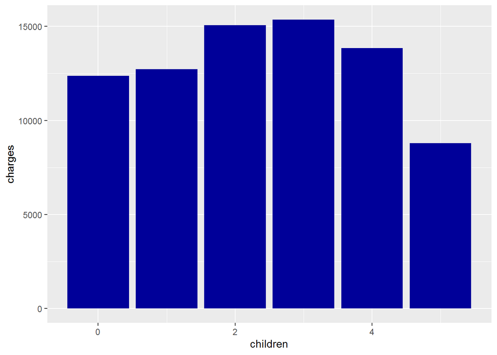

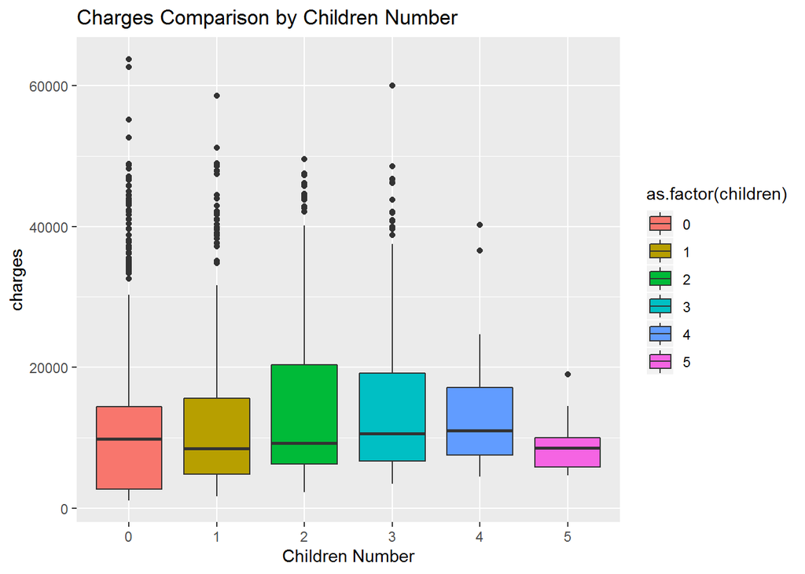

* People with no children spend less money in medical costs than people with up to four children. * People with 5 children spend the least average amount of money. * This data is influenced by the outliers. As we see in the boxplot.

Let’s see the charges behavior by region.

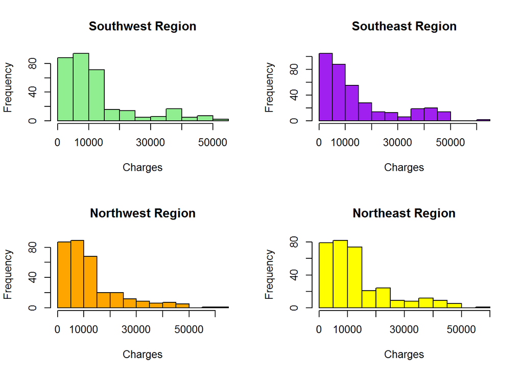

According to the plots, there is no difference in charges paid by people into each region.

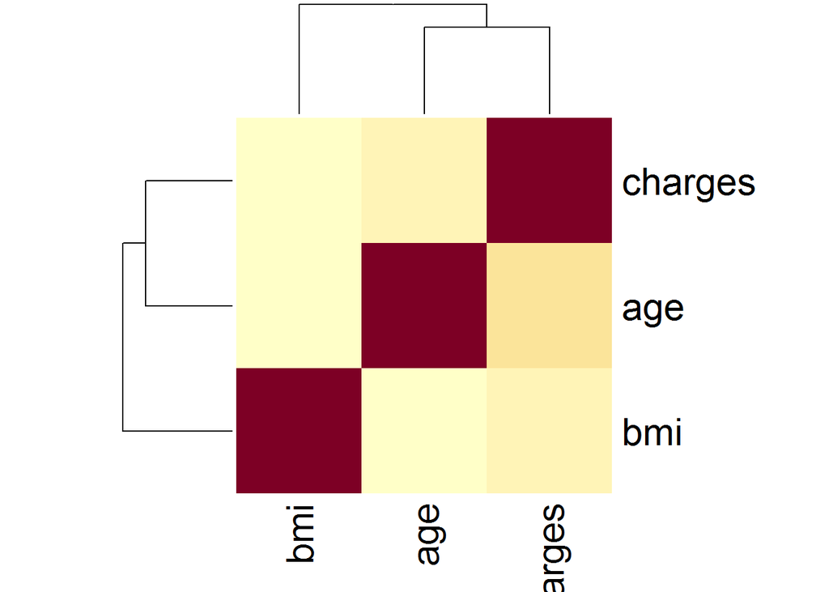

Correlations between continuous variables and the target column are relatively low.